# Dsembler User Manual

Aporva Gupta

July 12th, 2021

# **1. Launching Dsembler**

Dsembler can be installed via GitHub.

```bash
# obtain dsembler package from GitHub
$ git clone https://github.com/sblabkribb/dsembler.git
```

**Docker (recommended)**  
Users should have docker installed on their computer to run Dsembler locally. Docker can be downloaded from https://docs.docker.com/get-docker/. Ensure your BIOS settings are compatible with the docker application. Once docker is installed successfuly, run the following command in your terminal (or Powershell in Windows).

A Dsembler image will be built locally using the Dockerfile present in the Dsembler source folder. Alternatively, pull the image from docker using the following command

```bash
# build the docker image
$ docker build -t dsembler:latest .
OR
# pull image from dockerhub
$ docker pull sblabkribb/dsembler:latest
```

To run the web application, run the following command in your terminal or powershell.

Run docker container: Bash

```bash
$ docker run -d --rm -v $(pwd):/app --publish 5000:5000 --name dsembler dsembler
```

Run docker container: Powershell

```powershell
> docker run -d --rm -v %cd%:/app --publish 5000:5000 --name dsembler dsembler
```

This will run the Dsembler application on your localhost via port 5000.

**Python** Dsembler can be run from the user’s python environment as well. The user is responsible for installing the required packages (see requirements.txt) to run the program. Bash

```bash
$ export FLASK_APP=app
$ flask run
```

Powershell

```bash
> $env:FLASK_APP = "app"
> flask run
```

This would publish the application on your localhost:5000 port

# **2. Online Interface**

Dsembler has a simple, easy to use user interface.

## 2.1 Input

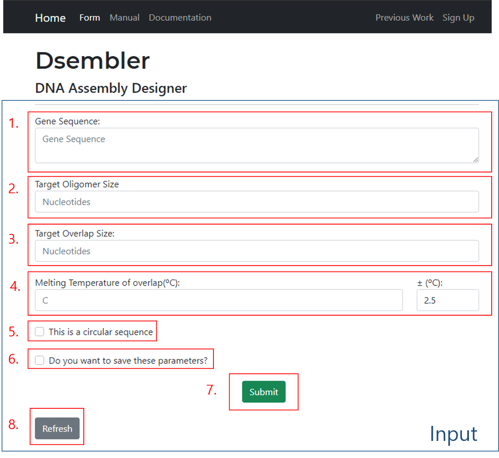

1. **Gene Sequence:** Users can input the gene sequence as plain text. The Application will not run if non-DNA elements are used (spaces and newlines are removed by the program automatically).
2. **Oligomer size:** Input the target oligomer size. The oligomers must be at least 50bp
3. **Overlap size:** Input the target overlap size. Overlaps must be at least 20bp and must be at least 30bp smaller than the target oligomer size.
4. **Melting Temperature & Temperature range:** The target melting temperature is inputted in ºC. An acceptable range is required from the user, i.e ± nºC. The default and minimum range is melting temp ± 2.5ºC. The recommended range is between 52 - 58<sup>o</sup>C. **Note:** the melting temperature is measured using the Melting Temperature of overlaps are calculated based on the Nearest Neighbour Equation and the Sugimoto (1996) thermodynamic table.
5. **Sequence Orientation:** Check the box if the Sequence you are using is circular. If left unchecked, the sequence is processed as a linear sequence
6. **Save Data:** If you’d like to save your parameters, check this box. An input form for your user ID is provided if checked. **Note:** you should have signed up to access previous records (See Sign up).
7. **Submit:** Click here to initiate oligomer generation.
8. **Refresh:** Click this to refresh the form.

## 2.2 Output

Two buttons appear on the same page once the target parameters are submitted: - Download the excel sheet output  
- Download the FASTA file

### 2.2.1 Excel File

The data is filled into the excel as the following columns.

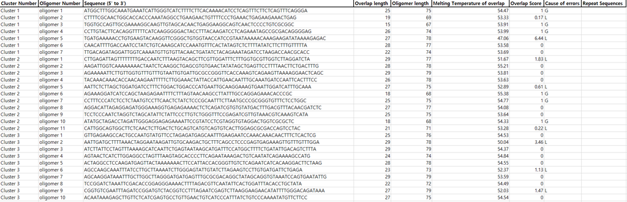

Excel Output File Example

| Cluster Number | Oligomer Number | Oligomer Sequence (5’ to 3’) | Overlap Length | Overlap Melting Temperature | Overlap Score | Score Faults | Repeats Sequences |
| --- | --- | --- | --- | --- | --- | --- | --- |

Overlap score is 0 if there are no possible areas of errors.

### 2.2.2 FASTA file

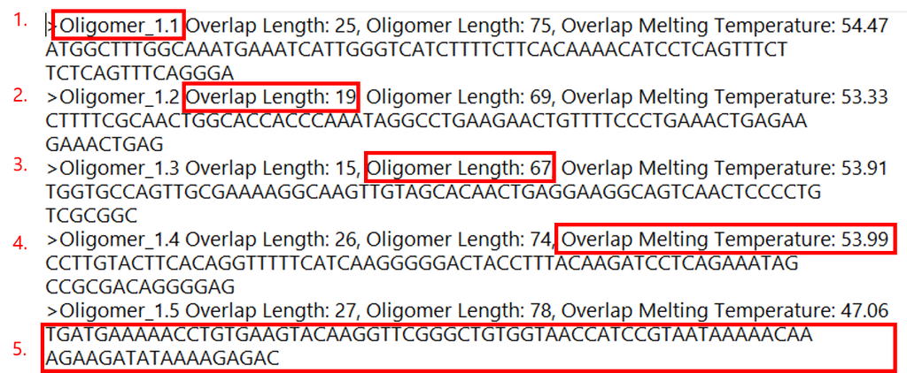

FASTA file output (Same example as Excel file; viewed on Notepad)

## 2.3 Previous Work

A simple SQLite based storage is used to provide users to store and access any previous work.

### 2.3.1 Sign up

First, you must register into the system by signing up.

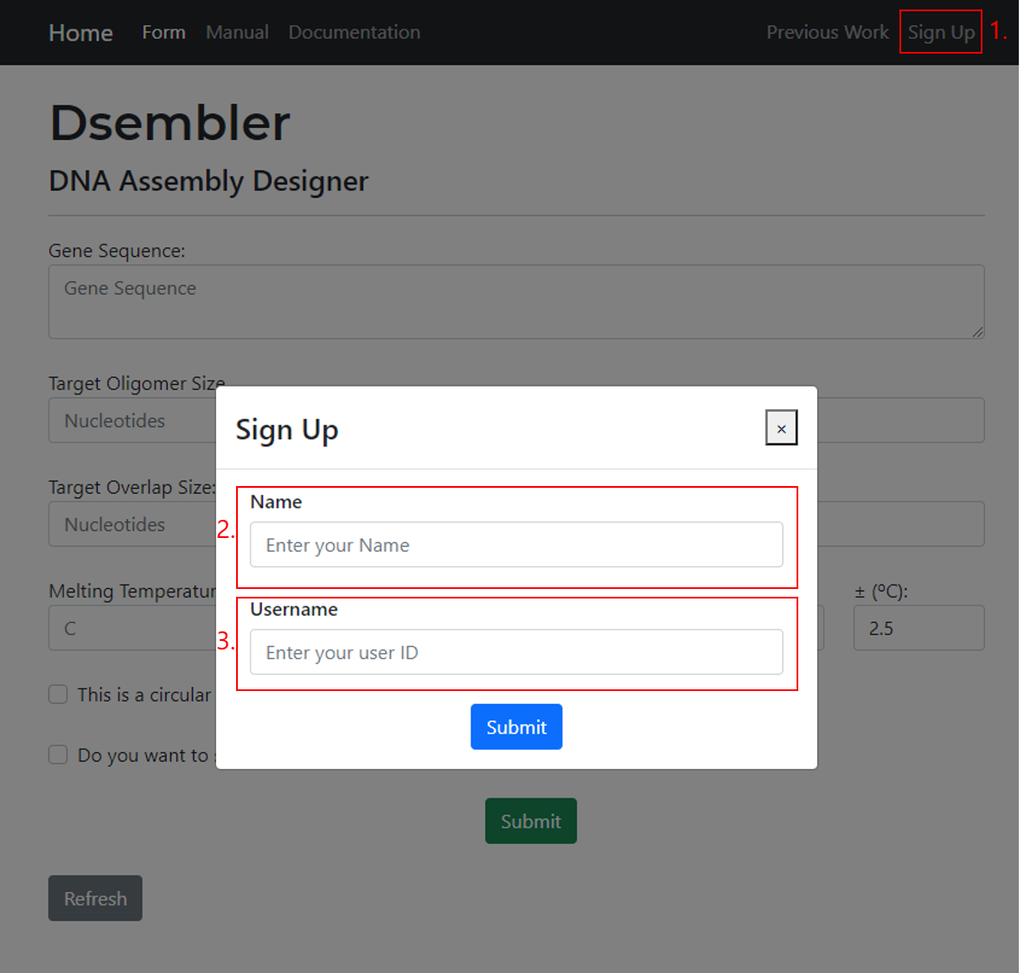

As the webpage does not cater to having password based logins, only the user’s name and preferred username is registered. Only unique ID’s are registered per container. Success and Failure messages are given appropriately.

### 2.3.2 Login

To access previous work, you must use your appropriate ID.

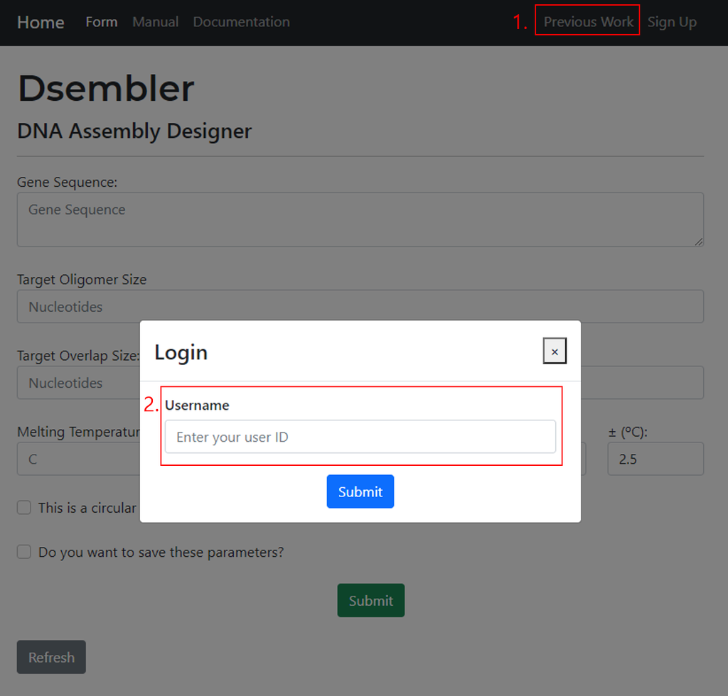

Once Logged in, you can find your previous queries, and can access the oligomers for the same.

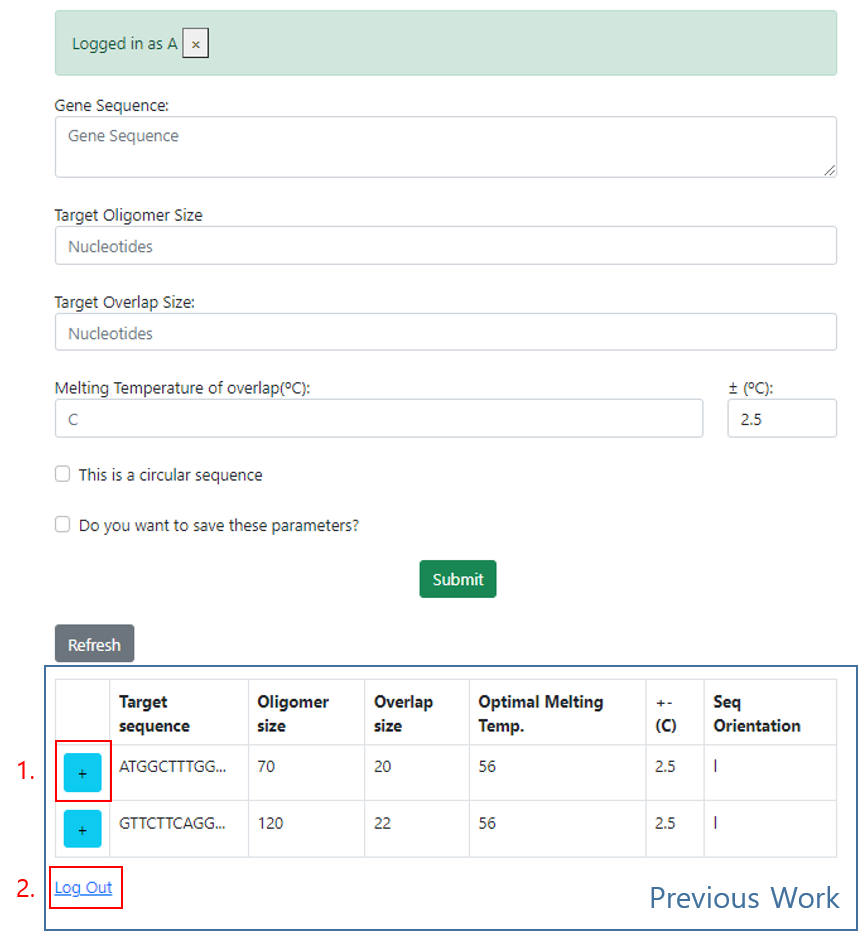

The oligomers for a specific query can be accessed by clicking on the blue ‘+’ button, which will generate the oligomers in a similar manner as shown in Output.

# 3. Contact

To report bugs and provide suggestions for the Dsembler User Interface and functionality, please contact the maintainer, Aporva Gupta (aporva03@kribb.re.kr)